# The ABC of Computational Text Analysis

#10 NLP with Python

Author

Affiliation

Alex Flückiger

Faculty of Humanities and Social Sciences  
University of Lucerne

Published

May 12, 2023

## Recap last Lecture

### introduce Python 🐍

- working with VS Code Editor
- learning programming concepts & syntax
  - data types, loops, indexing…

## Outline

- get the organizational stuff done
  - evaluation, mini-project, assignment #3
- let’s do serious NLP! ✨
- code interactively
  - interrupt, ask, and complement
- Fragen sehr wichtig, da gewaltiger Sprung zu letzter Session
- Stellschrauben kennen lernen, Gefühl für die Sprache entwickeln
  - Details vorerst unwichtig
- dritt letzte Sitzung, neue Inhalte nur noch heute und nächstes Mal
- stream via Zoom

# Organizational

## Tell me… 📣

### Please follow the link in the email

- received on 9 May 2023 (or similar)
- by the University of Lucerne, Faculty of Humanities and Social Sciences

### Thanks for any constructive feedback, be it sweet or sour! 🙏

- offene Kommentare nutzen, statt nur Kreuze
- 5min Zeit zum ausfüllen
- andere Code anschauen
- Tell me…
  - … what you disliked
  - … what you missed
  - … what you learned

## Assignment #3 ✍️

- get/submit via OLAT
  - starting tomorrow
  - deadline 20 May 2023, 23:59
- use the [OLAT](https://lms.uzh.ch/auth/RepositoryEntry/17174430971/CourseNode/91271815676815) forum
  - subscribe to get notifications
- ask friends for support, not solutions

## Requirements of Mini-Project

### present project on 2 June 2023

- analyze any collection of documents
  - compare historically
  - compare between actors
- apply quantitative measures + interpretation
  - executable script
  - multiple documents
- form groups of 2-4 people

❗ share your project idea [here](https://docs.google.com/spreadsheets/d/1VNyoCl7CsJXqko4DXw3ZwGo8QS055YEr42wjoUrkkZs/edit#gid=0) by 19 May 2023

- mini project online stellen?
- noch nicht alle in Liste?
- “Forschungsfrage” überlegen
- script ist gemachte arbeit zur wiederverwendung
- relative frequency 👍
- absolute frequency 👎

## Optional Seminar Paper

- writing a seminar paper (6 ECTS)
- get in touch to discuss your idea

# A Primer on Old School NLP

## What is a Word?

- words ~ segments between whitespace
- yet, there are …
  - contractions: `U.S.`, `don't`
  - collocations: `New York`

## Token

- token ~ computational unit
  - representation of words
- lemma ~ base form of a word
  - `texts` → `text`
  - `goes` → `go`
- stop words ~ functional words
  - lacking deeper meaning
  - `the`, `a`, `on`, `and` …

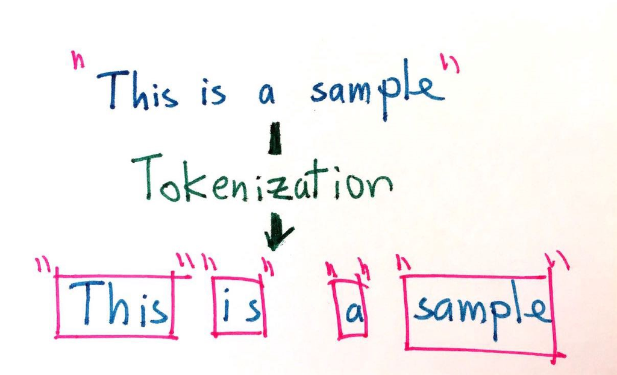

Tokenizing a sentence ([Medium](https://medium.com/data-science-in-your-pocket/tokenization-algorithms-in-natural-language-processing-nlp-1fceab8454af))

`Let's tokenize this sentence! Isn't is easy?` 🤓

- Text wird in seine Teile gesplittet
- Lemma ~ Form in Duden

## Common Processing Steps in NLP

1. Tokenizing
   - segmenting text into words, punctuations etc.
2. Tagging part-of-speech (POS)
   - assigning word types (e.g. verb, noun)
3. Parsing
   - describing syntactic relations
4. Named Entity Recognition (NER)
   - organizations, persons, locations, time etc.

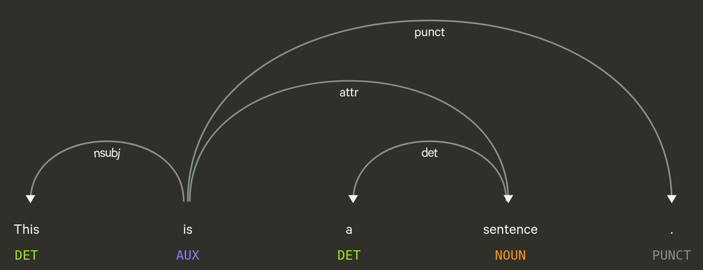

- Abfolge von Prozessierungsschritten
- alles sprachabhängig
- Tagging: ca. 20-30 POS tags
- Parsing
  - Verb ist Head von Satz
  - Subjekt-Verb-Objekt

## Modules/Packages

### No programming from scratch 🎉

- packages provide specific functionalities
- packages need to be installed first
- Standing on the shoulders of giants
- alles auf GitHub

## NLP Packages

- [spaCy](https://spacy.io/usage/spacy-101)
  - industrial-strength Natural Language Processing (NLP)
- [textaCy](https://textacy.readthedocs.io/en/latest/)
  - NLP, before and after spaCy
- scattertext
  - beautiful visualizations of how language differs across corpora

## Deep Dive into NLP for Social Science

- check [code](https://github.com/aflueckiger/KED2023/blob/main/materials/code/KED2023_10.ipynb) on GitHub
- run code on Binder

[figure not shown]

## Resources

#### tutorials on spaCy

- [official spaCy 101](https://spacy.io/usage/spacy-101)
- [official online course spaCy](https://course.spacy.io/en/)
- [Hitchhiker’s Guide to NLP in spaCy](https://www.kaggle.com/nirant/hitchhiker-s-guide-to-nlp-in-spacy)